# 01-dada2

18 January 2023

Processing primer-trimmed reads from Bristol Bay 2022 eDNA samples analyzed using metabarcoding with the salmonid Cyt B primer set.

```r
library(dada2)
library(dplyr)
# file location
path <- "/genetics/edna/workdir/bristolbay/trimmed"

path
```

```
[1] "/genetics/edna/workdir/bristolbay/trimmed"
```

```r
#list.files(path)
```

```r
fnFs <- sort(list.files(path, pattern = "_R1.fastq", full.names = TRUE))
fnRs <- sort(list.files(path, pattern = "_R2.fastq", full.names = TRUE))
# Extract sample names, assuming filenames have format: SAMPLENAME_XXX.fastq
sample.names <- sapply(strsplit(basename(fnFs), "_"), `[`, 1)
```

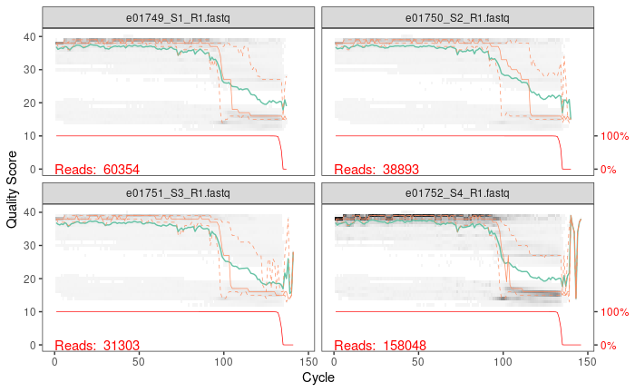

```r
plotQualityProfile(fnFs[1:4])
```

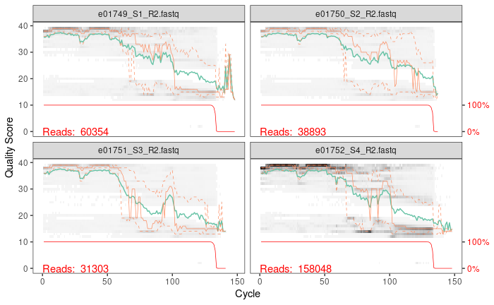

```r
plotQualityProfile(fnRs[1:4])
```

Yikes. The quality on these doesn’t look great. Based on these plots, I’d trim FWD reads at 100 bp and REV at 90 bp. Hopefully that’s enough overlap to combine FWD + REV.

```r
# Place filtered files in filtered/ subdirectory
filtFs <- file.path(path, "filtered", paste0(sample.names, "_F_filt.fastq.gz"))
filtRs <- file.path(path, "filtered", paste0(sample.names, "_R_filt.fastq.gz"))
names(filtFs) <- sample.names
names(filtRs) <- sample.names
```

Initial filtering truncLen failed miserably. We changed it to be super-stringent to see how that affects downstream processing.

```r
out <- filterAndTrim(fnFs, filtFs, fnRs, filtRs, truncLen=c(110,100),
              maxN=0, maxEE=c(2,4), truncQ=2, rm.phix=TRUE,
              compress=TRUE, multithread=TRUE)
head(out)
```

```
                   reads.in reads.out
e01749_S1_R1.fastq    60354     59994
e01750_S2_R1.fastq    38893     38733
e01751_S3_R1.fastq    31303     31051
e01752_S4_R1.fastq   158048    157708
e01753_S5_R1.fastq    40446     40373
e01754_S6_R1.fastq    48747     48655
```

If there are files with no reads, we must remove them from the file list - otherwise the dada2 algorithm (below) cannot be implemented.

```r
out %>%
  as.data.frame() %>%
  filter(reads.out <1)
```

| reads.in | reads.out |
| --- | --- |

```r
# filter the matrix to retain samples with >0 reads
```

```r
# tosser.names <- rownames(tossers)
# # move a set of files
# file.copy(from=file.path(paste0(path,"/", tosser.names)),
#           to=file.path(paste0(path, "/tossers","/", tosser.names)))
# # remove those from the original directory
# file.remove(from=file.path(paste0(path,"/",tosser.names)))
```

Let’s move fwd with these for now… and come back if there are other issues.

### Error rates

```r
errF <- learnErrors(filtFs, multithread=TRUE)
```

```
102209140 total bases in 929174 reads from 27 samples will be used for learning the error rates.
```

```r
errR <- learnErrors(filtRs, multithread=TRUE)
```

```
100551900 total bases in 1005519 reads from 30 samples will be used for learning the error rates.
```

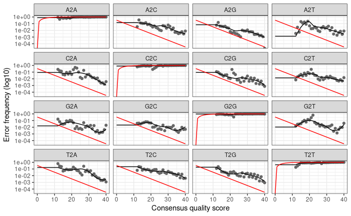

```r
plotErrors(errF, nominalQ=TRUE)
```

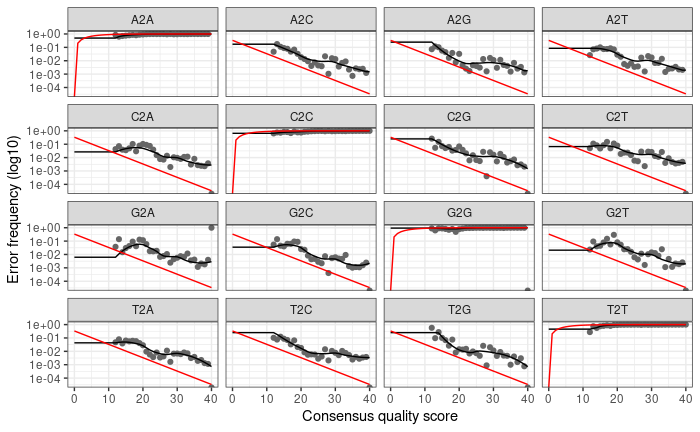

```r
plotErrors(errR, nominalQ=TRUE)
```

### Sample inference

```r
# forwards
dadaFs <- dada(filtFs, err=errF, pool="pseudo", multithread=TRUE)
```

```
Sample 1 - 59994 reads in 42361 unique sequences.
Sample 2 - 38733 reads in 23959 unique sequences.
Sample 3 - 31051 reads in 24930 unique sequences.
Sample 4 - 157708 reads in 116693 unique sequences.
Sample 5 - 40373 reads in 24770 unique sequences.
Sample 6 - 48655 reads in 44787 unique sequences.
Sample 7 - 26448 reads in 15424 unique sequences.
Sample 8 - 29736 reads in 19651 unique sequences.
Sample 9 - 18538 reads in 14807 unique sequences.
Sample 10 - 30130 reads in 16001 unique sequences.
Sample 11 - 37808 reads in 23051 unique sequences.
Sample 12 - 23738 reads in 15140 unique sequences.
Sample 13 - 28698 reads in 17854 unique sequences.
Sample 14 - 27076 reads in 12845 unique sequences.
Sample 15 - 10038 reads in 8298 unique sequences.
Sample 16 - 254 reads in 238 unique sequences.
Sample 17 - 25223 reads in 12637 unique sequences.
Sample 18 - 35063 reads in 18196 unique sequences.
Sample 19 - 47182 reads in 35564 unique sequences.
Sample 20 - 47046 reads in 38216 unique sequences.
Sample 21 - 24637 reads in 13224 unique sequences.
Sample 22 - 24277 reads in 9722 unique sequences.
Sample 23 - 37176 reads in 22254 unique sequences.
Sample 24 - 27761 reads in 20705 unique sequences.
Sample 25 - 1821 reads in 1287 unique sequences.
Sample 26 - 21436 reads in 16897 unique sequences.
Sample 27 - 28574 reads in 10151 unique sequences.
Sample 28 - 30156 reads in 10351 unique sequences.
Sample 29 - 23173 reads in 12271 unique sequences.
Sample 30 - 23016 reads in 16876 unique sequences.
Sample 31 - 34344 reads in 22148 unique sequences.
Sample 32 - 30289 reads in 13523 unique sequences.
Sample 33 - 39903 reads in 26794 unique sequences.
Sample 34 - 34229 reads in 18883 unique sequences.
Sample 35 - 29930 reads in 26421 unique sequences.
Sample 36 - 28644 reads in 21036 unique sequences.
Sample 37 - 27672 reads in 7432 unique sequences.
Sample 38 - 28163 reads in 24567 unique sequences.
Sample 39 - 33966 reads in 22598 unique sequences.
Sample 40 - 18444 reads in 15795 unique sequences.
```

[output cut: 19 more lines]

```
Sample 60 - 32629 reads in 20851 unique sequences.
Sample 61 - 22122 reads in 12508 unique sequences.
Sample 62 - 27211 reads in 22429 unique sequences.
Sample 63 - 27429 reads in 14487 unique sequences.
Sample 64 - 29968 reads in 25867 unique sequences.
Sample 65 - 13928 reads in 7542 unique sequences.
Sample 66 - 12805 reads in 6011 unique sequences.
Sample 67 - 22329 reads in 13224 unique sequences.
Sample 68 - 22734 reads in 12021 unique sequences.
Sample 69 - 16731 reads in 11142 unique sequences.
Sample 70 - 16432 reads in 12901 unique sequences.
Sample 71 - 21226 reads in 12187 unique sequences.
Sample 72 - 21424 reads in 12790 unique sequences.

   selfConsist step 2
```

```r
# reverses
dadaRs <- dada(filtRs, err=errR, pool="pseudo", multithread=TRUE)
```

```
Sample 1 - 59994 reads in 30010 unique sequences.
Sample 2 - 38733 reads in 23002 unique sequences.
Sample 3 - 31051 reads in 28515 unique sequences.
Sample 4 - 157708 reads in 77202 unique sequences.
Sample 5 - 40373 reads in 26647 unique sequences.
Sample 6 - 48655 reads in 21287 unique sequences.
Sample 7 - 26448 reads in 9338 unique sequences.
Sample 8 - 29736 reads in 11698 unique sequences.
Sample 9 - 18538 reads in 12750 unique sequences.
Sample 10 - 30130 reads in 8624 unique sequences.
Sample 11 - 37808 reads in 21539 unique sequences.
Sample 12 - 23738 reads in 14602 unique sequences.
Sample 13 - 28698 reads in 20555 unique sequences.
Sample 14 - 27076 reads in 16554 unique sequences.
Sample 15 - 10038 reads in 4406 unique sequences.
Sample 16 - 254 reads in 189 unique sequences.
Sample 17 - 25223 reads in 8202 unique sequences.
Sample 18 - 35063 reads in 9127 unique sequences.
Sample 19 - 47182 reads in 18998 unique sequences.
Sample 20 - 47046 reads in 35025 unique sequences.
Sample 21 - 24637 reads in 14145 unique sequences.
Sample 22 - 24277 reads in 13062 unique sequences.
Sample 23 - 37176 reads in 26911 unique sequences.
Sample 24 - 27761 reads in 8264 unique sequences.
Sample 25 - 1821 reads in 1434 unique sequences.
Sample 26 - 21436 reads in 14952 unique sequences.
Sample 27 - 28574 reads in 6402 unique sequences.
Sample 28 - 30156 reads in 7728 unique sequences.
Sample 29 - 23173 reads in 13600 unique sequences.
Sample 30 - 23016 reads in 21375 unique sequences.
Sample 31 - 34344 reads in 17754 unique sequences.
Sample 32 - 30289 reads in 15954 unique sequences.
Sample 33 - 39903 reads in 30063 unique sequences.
Sample 34 - 34229 reads in 12321 unique sequences.
Sample 35 - 29930 reads in 18253 unique sequences.
Sample 36 - 28644 reads in 9488 unique sequences.
Sample 37 - 27672 reads in 11123 unique sequences.
Sample 38 - 28163 reads in 27178 unique sequences.
Sample 39 - 33966 reads in 11614 unique sequences.
Sample 40 - 18444 reads in 6729 unique sequences.
```

[output cut: 19 more lines]

```
Sample 60 - 32629 reads in 14627 unique sequences.
Sample 61 - 22122 reads in 11151 unique sequences.
Sample 62 - 27211 reads in 21003 unique sequences.
Sample 63 - 27429 reads in 12113 unique sequences.
Sample 64 - 29968 reads in 13983 unique sequences.
Sample 65 - 13928 reads in 7575 unique sequences.
Sample 66 - 12805 reads in 3987 unique sequences.
Sample 67 - 22329 reads in 8363 unique sequences.
Sample 68 - 22734 reads in 11109 unique sequences.
Sample 69 - 16731 reads in 13625 unique sequences.
Sample 70 - 16432 reads in 15110 unique sequences.
Sample 71 - 21226 reads in 12975 unique sequences.
Sample 72 - 21424 reads in 8606 unique sequences.

   selfConsist step 2
```

Merge paired end reads

```r
mergers <- mergePairs(dadaFs, filtFs, dadaRs, filtRs, verbose=TRUE)
```

```
16345 paired-reads (in 50 unique pairings) successfully merged out of 57722 (in 373 pairings) input.
13886 paired-reads (in 77 unique pairings) successfully merged out of 36502 (in 512 pairings) input.
8141 paired-reads (in 39 unique pairings) successfully merged out of 29285 (in 146 pairings) input.
32116 paired-reads (in 87 unique pairings) successfully merged out of 153865 (in 510 pairings) input.
18650 paired-reads (in 31 unique pairings) successfully merged out of 38800 (in 96 pairings) input.
2313 paired-reads (in 28 unique pairings) successfully merged out of 48419 (in 114 pairings) input.
11250 paired-reads (in 54 unique pairings) successfully merged out of 26086 (in 204 pairings) input.
11010 paired-reads (in 67 unique pairings) successfully merged out of 29144 (in 326 pairings) input.
6015 paired-reads (in 62 unique pairings) successfully merged out of 17618 (in 279 pairings) input.
15337 paired-reads (in 46 unique pairings) successfully merged out of 29617 (in 103 pairings) input.
16191 paired-reads (in 55 unique pairings) successfully merged out of 35425 (in 194 pairings) input.
10465 paired-reads (in 74 unique pairings) successfully merged out of 22332 (in 294 pairings) input.
13300 paired-reads (in 37 unique pairings) successfully merged out of 26551 (in 77 pairings) input.
17608 paired-reads (in 49 unique pairings) successfully merged out of 25656 (in 85 pairings) input.
2162 paired-reads (in 19 unique pairings) successfully merged out of 9892 (in 97 pairings) input.
```

[output cut: 57 more lines]

```r
# Inspect the merger data.frame from the first sample
head(mergers[[1]])
```

|  | sequence | abundance | forward | reverse | nmatch | nmismatch | nindel | prefer | accept |
| --- | --- | --- | --- | --- | --- | --- | --- | --- | --- |
| 1 | TGCATTCGTAGGCTACGTCCTCCCATGAGGACAAATATCCTTCTGGGGAGCCACTGTAATTACAAACCTTCTTTCCGCTGTTCCGTACGTCGGGGGCGCCCTGGTACAATGAATTTGAGGCGGATTCTCCGTTGACAACGCCACTTTGACA | 5637 | 1 | 1 | 59 | 0 | 0 | 1 | TRUE |
| 6 | GACCACCGAGATCTACACAAACGGCGACAGGTTCAGAGTTCTACAGTCCGACGATCCTTCTCACTATAATAACCGACAGGTTCAGAGTTCTACAGTCCGACGATTTTTCGTCTTTCACAGATCGGAAGAGCACACGTCTGAACTCCAGTCACCGTGATATCTCGTATGCCGTCTTCTGCTTGA | 1370 | 2 | 3 | 27 | 0 | 0 | 1 | TRUE |
| 10 | GACCACCGAGATCTACACAAACGGCGACAGGTTCAGAGTTCTACAGTCCGACGATCCTTCTCACTATAATAACCGACAGGTTCAGAGTTCTACAGTCCGACGATTTTTCGGCTTTCACAGATCGGAAGAGCACACGTCTGAACTCCAGTCACCGTGATATCTCGTATGCCGTCTTCTGCTTGA | 1071 | 3 | 3 | 27 | 0 | 0 | 1 | TRUE |
| 17 | GACCACCGAGATCTACACAAACGGCGACAGGTTCAGAGTTCTACAGTCCGACGATCCTTCTCACTATAATAACCGACAGGTTCAGAGTTCTACAGTCCGACGATTTTTCGCCTTTCACAGATCGGAAGAGCACACGTCTGAACTCCAGTCACCGTGATATCTCGTATGCCGTCTTCTGCTTGA | 952 | 4 | 3 | 27 | 0 | 0 | 1 | TRUE |
| 22 | GACCACCGAGATCTACACAAACGGCGACAGGTTCAGAGTTCTACAGTCCGACGATCCTTCTCACTATAATGACCGACAGGTTCAGAGTTCTACAGTCCGACGATTTTTCGTCTTTCACAGATCGGAAGAGCACACGTCTGAACTCCAGTCACCGTGATATCTCGTATGCCGTCTTCTGCTTGA | 888 | 2 | 4 | 27 | 0 | 0 | 1 | TRUE |
| 23 | GACCACCGAGATCTACACAAACGGCGACAGGTTCAGAGTTCTACAGTCCGACGATCCTTCTCACTATAATAACCGACAGGTTCAGAGTTCTACAGTCCGACGATTTTTCGTCCTTCACAGATCGGAAGAGCACACGTCTGAACTCCAGTCACCGTGATATCTCGTATGCCGTCTTCTGCTTGA | 878 | 5 | 3 | 27 | 0 | 0 | 2 | TRUE |

Make a sequence table

```r
seqtab <- makeSequenceTable(mergers)
dim(seqtab)
```

```
[1]   72 2304
```

```r
# Inspect distribution of sequence lengths
table(nchar(getSequences(seqtab)))
```

```
110 111 112 113 114 115 116 117 118 119 120 121 122 123 124 125 126 127 128 129 130 131 132 133 134 135 136 137 138 139 140 141 142 143 144 145 146 147 148 149
 23   2   4   3   4   3   5   6   1   7   2   4   2   6   4   3   4   8   6   4   5   7   6   5   7   6   2  14   2   4   2   6   2   5   6  19   4   9  20   8
150 151 152 153 154 155 156 157 158 159 160 161 162 163 164 165 166 167 168 169 170 171 172 173 174 175 176 177 178 179 180 181 182 183 184 185 186 187 188 189
 11  79   4  13   1   6  11   8   6  16   8  11  22  59  21  13  10 170   7   3   4   5   2   2   2   6   4   3   4   7   7  10  17 935  57   3  70  26   6  32
190 191 192 193 194 195 196 197 198
 24  28  22  74 148   4  54   3  26
```

Let’s remove the singletons and off-target sequences

```r
seqtab2 <- seqtab[,nchar(colnames(seqtab)) %in% 183:187]
```

using the prior trimming (100, 90), the size was 163 rather than 183… expected fragment length (according to Damien Menning) is ~187 bp.

Remove chimeras

```r
seqtab.nochim <- removeBimeraDenovo(seqtab2, method="consensus", multithread=TRUE, verbose=TRUE)
```

```
Identified 360 bimeras out of 1091 input sequences.
```

```r
dim(seqtab.nochim)
```

```
[1]  72 731
```

Calculate frequency of chimeras

```r
sum(seqtab.nochim)/sum(seqtab2)
```

```
[1] 0.8738778
```

Track reads through the pipeline

```r
getN <- function(x) sum(getUniques(x))
track <- cbind(out, sapply(dadaFs, getN), sapply(dadaRs, getN), sapply(mergers, getN), rowSums(seqtab.nochim))

colnames(track) <- c("input", "filtered", "denoisedF", "denoisedR", "merged", "nonchim")
rownames(track) <- sample.names
head(track)
```

```
        input filtered denoisedF denoisedR merged nonchim
e01749  60354    59994     59033     58557  16345    8848
e01750  38893    38733     37285     37841  13886    4224
e01751  31303    31051     30618     29659   8141    7928
e01752 158048   157708    156856    154390  32116       0
e01753  40446    40373     40277     38850  18650       0
e01754  48747    48655     48509     48558   2313     452
```

```r
# output that info for the initial trimming (100, 90)
track %>%
  write.csv("csv_outputs/trimmed_110_100_reads.csv")
```

I almost wonder if using just the FWD reads would be more successful. There’s also always the question of whether there was an issue with the library prep (beads or ethanol left in the final elution).

## Export files for taxonomy and samples/ASVs

```r
 #make fasta file with ASVs
    asv_seqs=colnames(seqtab.nochim)
    for(i in 1:length(asv_seqs))
    {
        write.table(paste(">ASV",i, sep=""),file="csv_outputs/bristolbay_ASV_seqtab_nochim.csv", append=TRUE, col.names = F, row.names = F, quote=F)
        write.table(paste(asv_seqs[i], sep=""),file="csv_outputs/bristolbay_ASV_seqtab_nochim.csv", append=TRUE, col.names = F, row.names = F, quote=F)
    }
```

That’s the input for the FASTA blastn search.

```r
# Make map between brief names and full sequences
briefToSeq <- colnames(seqtab.nochim)
names(briefToSeq) <- paste0("ASV", seq(ncol(seqtab.nochim))) # Seq1, Seq2, ...
# Make new sequence table with brief names
st.brief <- seqtab.nochim
colnames(st.brief) <- names(briefToSeq)

# export the pool seq table with brief names:
write.csv(st.brief, file="csv_outputs/bristolbay_ASVtable.csv")
```